# Enfoque Estadístico del Aprendizaje - Trabajo Final

Especialización en Explotación de datos y Descubrimiento del conocimiento

Alba Nahuel - Federico Picado

```r
knitr::opts_chunk$set(echo = TRUE)
```

Las librerías utilizadas se muestran a continuacion:

```r
library(GGally)
library(tidyverse)
library (rmarkdown)
library(readxl)
library(readr)
library(ggplot2)
library(ggthemes)
library(GGally)
library (tidymodels)
library (lmtest)
library (car)
library(lme4)
library(lmerTest)
library(MuMIn)
```

# Carga de datos y analisis descriptivo.

```r
data <- read_excel("Larval_counts_emergence_time_and_adult_body_mass.xlsx", sheet = "VarE")
```

Como esta compuesto el dataset?

```r
names(data)
```

```
[1] "block.no"    "lar.density" "rep"         "sex"         "dev.time"    "b.mass.em"
```

Variable dependiente:

- *b.mass.em*: Cuantitativa continua (mg).

Variables explicativas:

- *lar.density*: Variable de efectos fijos, cualitativa.
- *dev.time*: Variable de efectos fijos, cuantitativa continua (horas).
- *rep*: Variable de efectos aleatorios, cualitativa.

```r
#elimino filas donde b.mass.em = "na"
data <- data %>%
  filter(b.mass.em != "na") %>%
  mutate(b.mass.em = round(as.numeric(b.mass.em), 3)) %>%
  mutate(dev.time = round(as.numeric(dev.time), 0)) %>%
  select(-block.no)
```

```r
# Convertir columnas categóricas a factores
data <- data %>%
  mutate(
    lar.density = as.factor(lar.density),
    sex = as.factor(sex),
    rep = as.factor(rep)
  )
```

Vemos las diferencias que hay en biomasa para hembras y machos.

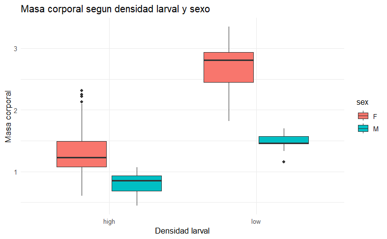

```r
# Boxplot: Relación entre densidad larval, sexo, y masa corporal
ggplot(data, aes(x = lar.density, y = b.mass.em, fill = sex)) +
  geom_boxplot() +
  labs(
    title = "Masa corporal segun densidad larval y sexo",
    x = "Densidad larval",
    y = "Masa corporal"
  ) +
  theme_minimal()
```

```r
data %>%
  count(sex)
```

| sex | n |
| --- | --- |
| F | 333 |
| M | 38 |

```r
data_female= data %>%
  filter(sex=="F")
```

El nombre de la replica era el mismo ya sea para alta densidad de larvas o baja. Cada grupo de muestras independientes entre si tiene que tener un identificador unico.

```r
data_female <- data_female %>%
  filter(rep %in% as.character(1:8))

data_female <- data_female %>%
  mutate(rep = if_else(lar.density == "high", as.numeric(rep) + 8, as.numeric(rep)))
```

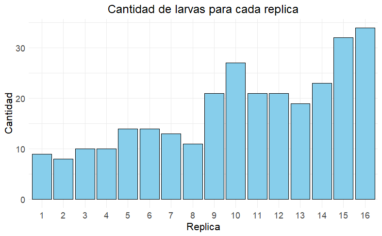

```r
data_female %>%
  group_by(rep) %>%
  summarise(n = n()) %>%
  ggplot(aes(x = as.factor(rep), y = n)) +
  geom_bar(stat = "identity", fill = "skyblue", color = "black") +
  labs(
    x = "Replica",
    y = "Cantidad",
    title = "Cantidad de larvas para cada replica"
  ) +
  theme_minimal() +
  theme(
    plot.title = element_text(hjust = 0.5, size = 16),
    axis.title = element_text(size = 14),
    axis.text = element_text(size = 12)
  )
```

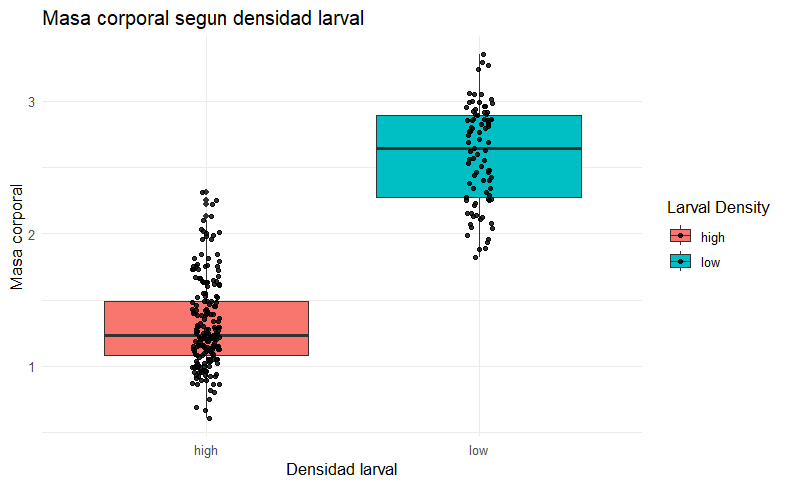

```r
ggplot(data_female, aes(x = lar.density, y = b.mass.em, fill = lar.density)) +
  geom_boxplot() +
  scale_color_brewer(palette = "Set2") +
  geom_jitter(
    size = 1.2,
    alpha = 0.8,
    color = "black", # Color negro para los puntos
    position = position_jitterdodge(jitter.width = 0.2, dodge.width = 0.75)
  )+
  labs(
    title = "Masa corporal segun densidad larval",
    x = "Densidad larval",
    y = "Masa corporal",
    fill = "Larval Density"
  ) +
  theme_minimal()
```

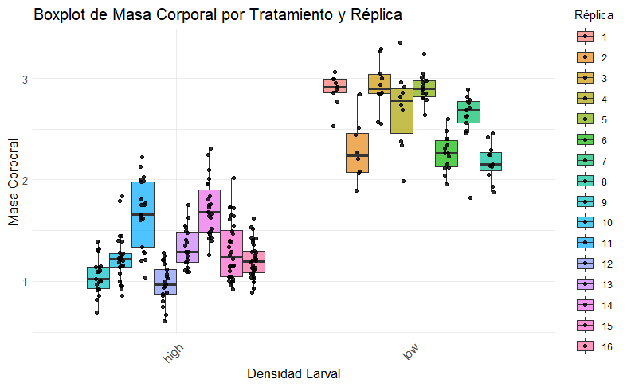

```r
ggplot(data_female, aes(x = lar.density, y = b.mass.em, fill = factor(rep))) +
  geom_boxplot(
    outlier.shape = NA,
    alpha = 0.7,
    position = position_dodge(width = 0.75)
  ) +
  geom_jitter(
    size = 1.2,
    alpha = 0.8,
    color = "black",
    position = position_jitterdodge(jitter.width = 0.2, dodge.width = 0.75)
  )+
  scale_fill_manual(values = scales::hue_pal()(16), name = "Réplica") +
  scale_color_manual(values = scales::hue_pal()(16), name = "Réplica")+
  labs(
    x = "Densidad Larval",
    y = "Masa Corporal",
    title = "Boxplot de Masa Corporal por Tratamiento y Réplica"
  ) +
  theme_minimal() +
  theme(
    legend.position = "right",
    legend.title = element_text(size = 10),
    legend.text = element_text(size = 8),
    axis.text.x = element_text(size = 10, angle = 45, hjust = 1),
    strip.text = element_text(size = 10, face = "bold")
  )
```

Mediante la aplicación de un modelo mixto, que incluye efectos fijos y aleatorios, podemos representar con mayor precisión la variabilidad natural existente entre las diferentes réplicas. Mientras que los efectos fijos permiten evaluar el impacto específico del experimento, los efectos aleatorios se enfocan en la variación que surge de cada réplica.

Si no incluyo efectos aleatorios en el modelo, una parte de la variabilidad entre las unidades experimentales se queda sin modelar y, por lo tanto, se acumula en los residuos. Esto llevara a un menor porcentaje de variabilidad explicada por el modelo.

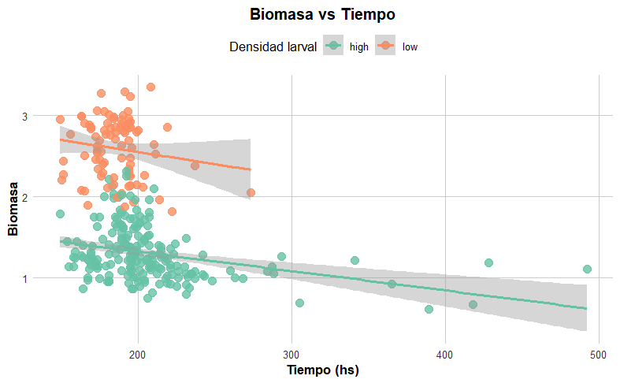

```r
ggplot(data_female, aes(x = dev.time, y =b.mass.em, color = lar.density)) +
  geom_point(size = 3, alpha = 0.8) +
    geom_smooth(
    method = "lm",
    formula = y ~ x ,
    se = TRUE,
    size = 1.2
  )+
  scale_color_brewer(palette = "Set2") +
  labs(
    title = "Biomasa vs Tiempo",
    x = "Tiempo (hs)",
    y = "Biomasa",
    color = "Densidad larval"
  ) +
  theme_minimal() +
  theme(
    plot.title = element_text(face = "bold", hjust = 0.5),
    legend.position = "top",
    panel.grid.major = element_line(color = "grey80"),
    panel.grid.minor = element_blank(),
    axis.title = element_text(face = "bold"),
    axis.text = element_text(color = "grey20")
)
```

Los mosquitos se pesan cuando llegan a su estado adulto, en este grafico vemos que los mosquitos que estan bajo el tratamiento de alta densidad tardar mas horas en llegar a su estado adulto, el cual puede durar entre 7 y 14 dias aproximadamente.

# Modelo lineal multiple con efectos aleatorios.

Se plantearon y evaluaron distintos modelos, que se muestran a contiuacion:

```r
# Modelos
m0= lmer(b.mass.em ~ (1 | rep), data = data_female)

m1= lmer(b.mass.em ~ dev.time * lar.density + (1|rep), data=data_female) #no da significativa la interacion.

m2= lmer(b.mass.em ~ dev.time + lar.density + (1|rep), data=data_female)

m3= lmer(b.mass.em ~ dev.time + (1|rep), data=data_female)

m4= lmer(b.mass.em ~ lar.density + (1|rep), data=data_female)
```

Comparamos cada uno de los modelos usando un test de verosimilitud. Hay una mejora significativa del ajuste entre cada modelo?

```r
anova(m2, m4)
```

```
refitting model(s) with ML (instead of REML)
```

```
Data: data_female
Models:
m4: b.mass.em ~ lar.density + (1 | rep)
m2: b.mass.em ~ dev.time + lar.density + (1 | rep)
   npar    AIC    BIC   logLik deviance  Chisq Df Pr(>Chisq)
m4    4 48.962 63.600 -20.4812   40.962
m2    5 15.681 33.979  -2.8406    5.681 35.281  1  2.854e-09 ***
---
Signif. codes:  0 ‘***’ 0.001 ‘**’ 0.01 ‘*’ 0.05 ‘.’ 0.1 ‘ ’ 1
```

```r
summary(m1)
```

```
Linear mixed model fit by REML. t-tests use Satterthwaite's method ['lmerModLmerTest']
Formula: b.mass.em ~ dev.time * lar.density + (1 | rep)
   Data: data_female

REML criterion at convergence: 36

Scaled residuals:
    Min      1Q  Median      3Q     Max
-3.2400 -0.5994 -0.0937  0.5574  3.1160

Random effects:
 Groups   Name        Variance Std.Dev.
 rep      (Intercept) 0.07756  0.2785
 Residual             0.05046  0.2246
Number of obs: 287, groups:  rep, 16

Fixed effects:
                          Estimate Std. Error         df t value Pr(>|t|)
(Intercept)              1.767e+00  1.268e-01  3.425e+01  13.939 1.11e-15 ***
dev.time                -2.198e-03  3.779e-04  2.705e+02  -5.817 1.68e-08 ***
lar.densitylow           1.396e+00  3.329e-01  1.843e+02   4.193 4.27e-05 ***
dev.time:lar.densitylow -8.840e-04  1.623e-03  2.811e+02  -0.545    0.586
---
Signif. codes:  0 ‘***’ 0.001 ‘**’ 0.01 ‘*’ 0.05 ‘.’ 0.1 ‘ ’ 1

Correlation of Fixed Effects:
            (Intr) dev.tm lr.dns
dev.time    -0.617
lar.dnstylw -0.381  0.235
dv.tm:lr.dn  0.144 -0.233 -0.904
```

```r
summary(m2)
```

```
Linear mixed model fit by REML. t-tests use Satterthwaite's method ['lmerModLmerTest']
Formula: b.mass.em ~ dev.time + lar.density + (1 | rep)
   Data: data_female

REML criterion at convergence: 25.3

Scaled residuals:
    Min      1Q  Median      3Q     Max
-3.2189 -0.5849 -0.0782  0.5530  3.0625

Random effects:
 Groups   Name        Variance Std.Dev.
 rep      (Intercept) 0.07717  0.2778
 Residual             0.05035  0.2244
Number of obs: 287, groups:  rep, 16

Fixed effects:
                 Estimate Std. Error         df t value Pr(>|t|)
(Intercept)     1.777e+00  1.252e-01  3.295e+01  14.192 1.36e-15 ***
dev.time       -2.246e-03  3.671e-04  2.723e+02  -6.119 3.26e-09 ***
lar.densitylow  1.232e+00  1.422e-01  1.398e+01   8.665 5.39e-07 ***
---
Signif. codes:  0 ‘***’ 0.001 ‘**’ 0.01 ‘*’ 0.05 ‘.’ 0.1 ‘ ’ 1

Correlation of Fixed Effects:
            (Intr) dev.tm
dev.time    -0.606
lar.dnstylw -0.592  0.059
```

La ecuacion formal del modelo seria:

$$b.mass.em = \beta_0 + \beta_1\ * dev.time + \beta_2\ * lar.density\ low
+ B_k + \epsilon$$

En los modelos mixtos, se asume que los efectos aleatorios provienen de una distribución normal con media cero y una varianza dada por las replicas. Al incorporar estos efectos, se espera que una vez ajustado el modelo, las observaciones sean independientes unas de otras dado que la fuente principal de variación adicional (capturada por los efectos aleatorios) ya está incorporada. Como resultado, los residuos deberían carecer de patrones evidentes y distribuirse de forma aproximadamente normal.

```r
res <- resid(m2)
pred <- predict(m2)

Bk <- ranef(m2)$rep$'(Intercept)'

par(mfrow = c(1, 3))
plot(pred, res, xlab="Predichos", ylab="Residuos", main="Residuos vs Predicciones")
abline(h=0, col="red")
```

```r
qqnorm(res, main="QQ-plot Residuos")
qqline(res)
```

```r
qqnorm(Bk, main="QQ-plot Efectos aleatorios")
qqline(Bk)
```

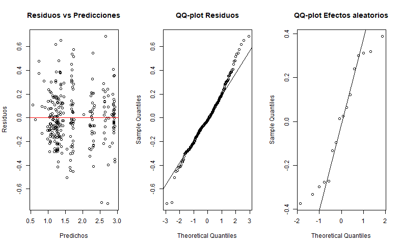

```r
par(mfrow = c(1, 1))
```

```r
shapiro.test(res)
```

```
    Shapiro-Wilk normality test

data:  res
W = 0.98617, p-value = 0.007349
```

```r
shapiro.test(Bk)
```

```
    Shapiro-Wilk normality test

data:  Bk
W = 0.9189, p-value = 0.1619
```

Dado que no se cumple el supuesto de normalidad, transformamos la variable respuesta biomasa a logaritmo, teniendo asi un modelo Log-Nivel.

```r
# Transformación logarítmica
data_female$log_b.mass.em <- log(data_female$b.mass.em)

# Ajustar el modelo con la variable transformada
m2_log <- lmer(log_b.mass.em ~ dev.time + lar.density + (1|rep), data = data_female)
```

Este nuevo modelo cumple los supuestos antes mencionados?

```r
res <- resid(m2_log)
pred <- predict(m2_log)

Bk <- ranef(m2_log)$rep$'(Intercept)'

par(mfrow = c(1, 3))
plot(pred, res, xlab="Predichos", ylab="Residuos", main="Residuos vs Predicciones")
abline(h=0, col="red")
```

```r
qqnorm(res, main="QQ-plot Residuos")
qqline(res)
```

```r
qqnorm(Bk, main="QQ-plot Efectos aleatorios")
qqline(Bk)
```

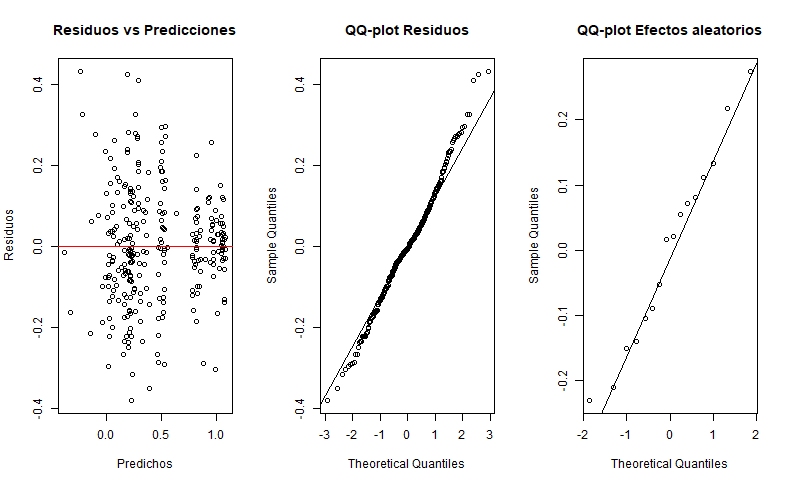

```r
par(mfrow = c(1, 1))
```

```r
shapiro.test(res)
```

```
    Shapiro-Wilk normality test

data:  res
W = 0.9914, p-value = 0.09222
```

```r
shapiro.test(Bk)
```

```
    Shapiro-Wilk normality test

data:  Bk
W = 0.97175, p-value = 0.8661
```

```r
#Resumen del modelo
summary(m2_log)
```

```
Linear mixed model fit by REML. t-tests use Satterthwaite's method ['lmerModLmerTest']
Formula: log_b.mass.em ~ dev.time + lar.density + (1 | rep)
   Data: data_female

REML criterion at convergence: -229.9

Scaled residuals:
     Min       1Q   Median       3Q      Max
-2.64213 -0.59609 -0.03647  0.55678  2.99485

Random effects:
 Groups   Name        Variance Std.Dev.
 rep      (Intercept) 0.02479  0.1574
 Residual             0.02074  0.1440
Number of obs: 287, groups:  rep, 16

Fixed effects:
                 Estimate Std. Error         df t value Pr(>|t|)
(Intercept)     6.246e-01  7.469e-02  3.974e+01   8.363 2.70e-10 ***
dev.time       -1.863e-03  2.355e-04  2.731e+02  -7.912 6.33e-14 ***
lar.densitylow  6.614e-01  8.109e-02  1.429e+01   8.155 9.51e-07 ***
---
Signif. codes:  0 ‘***’ 0.001 ‘**’ 0.01 ‘*’ 0.05 ‘.’ 0.1 ‘ ’ 1

Correlation of Fixed Effects:
            (Intr) dev.tm
dev.time    -0.652
lar.dnstylw -0.572  0.066
```

Los coeficientes son estadísticamente significativos, lo cual indica que dev.time y lar.densitylow tienen un efecto sobre la biomasa.

El intercepto no tiene valor interpretativo ya que a tiempo 0 el mosquito no se ha desarrollado aun.

El valor del coeficiente estimado para dev.time es de -0.001863, por lo que por cada aumento unitario en horas la biomasa corporal de los mosquitos al llegar al estado adulto disminuye en promedio 0.186%, manteniendo el resto de variables constantes.

El coeficiente negativo asociado a dev.time no indica que el mosquito esté perdiendo masa a lo largo del tiempo de forma dinámica. No se esta midiendo la masa repetidamente en el mismo individuo conforme pasan las horas, sino que aquellos mosquitos que toman más tiempo en completar su desarrollo y emerger como adultos tienden a tener menor biomasa al momento de la medición final.

El valor del coeficiente estimado para lar.densitylow es de 0.6614, lo que significa que en promedio los mosquitos con tratamiento low en comparacion con tratamiento high tienen una ganancia del 66,14% en la biomasa, manteniendo dev.time constante.

# Coeficiente de correlacion intraclase:

Mide la variabilidad aportada por cada variable explicatoria con efectos aleatorios. Se calculo como CCI = Varianza replica dividido la varianza de la replica más la varianza general del modelo. Valores altos de cci son indicativos de que la variabilidad de la variable dependiente es explicada por los variación entre replicas. En definitiva, es reflejo de la heterogeneidad de las replicas al aportar variabilidad en la explicación del fenómeno.

```r
#Calculo del ICC

var_rep <- as.data.frame(VarCorr(m2_log))$vcov[1]
var_residual <- attr(VarCorr(m2_log), "sc")^2

icc <- var_rep / (var_rep + var_residual)
icc
```

```
[1] 0.5445068
```

El 54% de la variación aleatoria (no impuesta por el experimento) en la biomasa de los mosquitos esta explicada por la variación en las replicas.

```r
r2_values <- r.squaredGLMM(m2_log)
print(r2_values)
```

```
           R2m       R2c
[1,] 0.7080193 0.8670048
```

Incluyendo los efectos aleatorios al modelos logro explicar un 86,7% de la variabilidad de los datos.

Por ultimo, se pueden realizar predicciones en base a una replica particular.

$$\text{BLUP}_j = \text{BLUE}_j \left(
\frac{\sigma^2_{\text{rep}}}{\sigma^2_{\text{rep}} +
\frac{\sigma^2}{n_i}} \right)$$

El BLUP permite predecir el efecto aleatorio de un grupo determinado teniendo en cuenta tanto la información propia de ese grupo (sus datos individuales) como la información global del conjunto de datos (la población general). Ademas, si un determinado grupo tiene pocos datos o datos poco fiables, el BLUP “encoge” esa predicción hacia la media global, evitando estimaciones extremas y reduciendo el error de predicción.

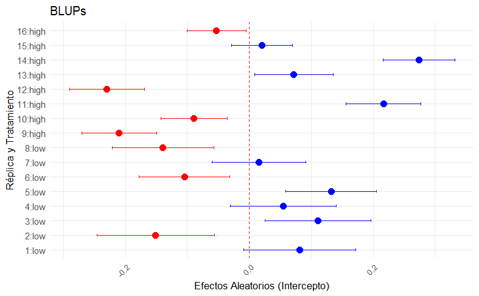

```r
ranef_m2_log <- ranef(m2_log, condVar = TRUE)
ranef_df <- as.data.frame(ranef_m2_log$`rep`)

ranef_df$upper <- ranef_df$`(Intercept)` + 1.96 * sqrt(attr(ranef_m2_log$`rep`, "postVar")[1, 1, ])
ranef_df$lower <- ranef_df$`(Intercept)` - 1.96 * sqrt(attr(ranef_m2_log$`rep`, "postVar")[1, 1, ])


ranef_df$group <- rownames(ranef_df)
ranef_df$group <- ifelse(as.integer(ranef_df$group) <= 8,
                         paste0(ranef_df$group, ":low"),
                         paste0(ranef_df$group, ":high"))

ranef_df$intercept <- ranef_df$`(Intercept)`
ranef_df$group <- factor(ranef_df$group,
                         levels = c("1:low", "2:low", "3:low", "4:low",
                                    "5:low", "6:low", "7:low", "8:low",
                                    "9:high", "10:high", "11:high", "12:high",
                                    "13:high", "14:high", "15:high", "16:high"))

ggplot(ranef_df, aes(x = group, y = intercept, ymin = lower, ymax = upper, color = intercept > 0)) +
  geom_point(size = 3) +
  geom_errorbar(width = 0.2) +
  geom_hline(yintercept = 0, linetype = "dashed", color = "red") +
  scale_color_manual(values = c("red", "blue"), guide = "none") +
  labs(
    title = "BLUPs",
    x = "Réplica y Tratamiento",
    y = "Efectos Aleatorios (Intercepto)"
  ) +
  theme_minimal() +
  theme(
    axis.text.y = element_text(size = 10),
    axis.text.x = element_text(angle = 45, hjust = 1)
  ) +
  coord_flip()
```

Este gráfico muestra la desviación de cada réplica con respecto al intercepto promedio estimado por el modelo mixto. En otras palabras, presenta cómo cada réplica se “desvía” de la media general, una vez que hemos tenido en cuenta el efecto fijo de la densidad larval y las relaciones entre la masa corporal y el tiempo de desarrollo.

Las barras horizontales representan intervalos de confianza alrededor del efecto aleatorio de cada réplica. Algunas réplicas presentan valores por encima de cero (efectos aleatorios positivos), indicando que, incluso controlando por los efectos fijos, esos ensayos tienden a producir masas corporales mayores a lo esperado.